# hurricane_sst_v2.Rmd

These mapping examples were created for a Nature Toolbox article by Jeffrey Perkel, published 7 June 2018.

In the first example, we will plot the US National Hurricane Center forecast track for Atlantic hurricane Irma using publicly available data (advisory #20, 0900 GMT on 04 September 2017), overlaid with potential coastal targets.

First, load required libraries.

```r
#############################################################################################
# Author: Luke Miller, Mar 12, 2018
# Author: Jeffrey Perkel, Mar 15, 2018
#############################################################################################

# install.packages('tidyverse')
# install.packages('sf')
# install.packages('raster')
# install.packages('mapview')

library(tidyverse)
library (sf)
library (leaflet)
library (mapview)
library (rgdal)
library (raster)
library (geojsonio)
```

Next, read in data. These latitude and longitude data were obtained from Google Maps. The Irma data source is NHC: https://www.nhc.noaa.gov/gis/forecast/archive/al112017_5day_020.zip

```r
df <- read.csv(textConnection(
"Name,Lat,Long
Barbuda,17.648,-61.779
Sint Maarten,18.060,-63.049
British Virgin Islands,18.349,-64.718
Santo Domingo,18.483,-69.929
San Juan,18.421,-66.059
Havana,23.111,-82.357
Key West,24.555, -81.779
Miami Beach,25.790,-80.135
New Orleans,29.999,-90.087
Houston,29.782,-95.405
"))

# Import the advisory 'shape' files...
irmaPolygon <-
  readOGR("/Users/jeffreyperkel/Downloads/al112017_5day_020/al112017-020_5day_pgn.shp")
irmaLine <-
  readOGR("/Users/jeffreyperkel/Downloads/al112017_5day_020/al112017-020_5day_lin.shp")
irmaPoints <-
  readOGR("/Users/jeffreyperkel/Downloads/al112017_5day_020/al112017-020_5day_pts.shp")
```

Plot the map using Leaflet. Color the coastal cities in blue, the hurricane in red, and give the polygon a black border. Add text to label the figure. And center it on Havana, Cuba.

```r
labels <- as.data.frame(irmaPoints)$FLDATELBL

m <- leaflet ()
m <- addProviderTiles(m, providers$OpenTopoMap)
m <- addPolygons(m, data = irmaPolygon, color = "black", weight = "2", fillColor="red", fillOpacity = 0.3)
m <- addPolylines(m, data = irmaLine)
m <- addCircleMarkers(m, data = irmaPoints, color = "red", radius = 2, label = labels,
                      labelOptions = labelOptions(noHide = TRUE, textOnly = TRUE))
m <- addCircleMarkers(m, lat=df$Lat,lng=df$Long,label=df$Name, radius = 2,
                      labelOptions = labelOptions(noHide = TRUE, textOnly = TRUE))
m <- setView(m, -82.357,23.111,zoom=4)

m
```

[interactive chart not shown]

Let’s overlay SST data for the same day, 4 September 2017. This code comes from Luke Miller at San Jose State University in California and is based on his 2014 blog post: https://lukemiller.org/index.php/2014/11/extracting-noaa-sea-surface-temperatures-with-ncdf4/. It retrieves sea surface temperatures for a given latitude/longitude and date.

```r
# Basic OISST data load

# customize for your computer
source ("~/Downloads/NOAA_OISST_ncdf4.R")

ssts = extractOISSTdaily("~/Downloads/sst.day.mean.2017.nc","~/Downloads/lsmask.oisst.v2.nc", lonW=160, lonE=359, latS=-10, latN=60, date1='2017-09-04', date2='2017-09-05')

s = brick(ssts,
          xmn = as.numeric(attr(ssts, 'dimnames')$Long[1]),
          xmx = as.numeric(attr(ssts, 'dimnames')$Long[ncol(ssts)]),
          ymn = as.numeric(attr(ssts, 'dimnames')$Lat[nrow(ssts)]),
          ymx = as.numeric(attr(ssts, 'dimnames')$Lat[1]),
          crs = '+proj=longlat +datum=WGS84')
s = dropLayer(s, 2)

# Necessary steps to get leaflet to plot western hemi data
# See https://github.com/r-spatial/mapview/issues/6
b = shift(s, -360)
SST <- crop(b, extent(-100,180,-90,90),snap='in') %>% trim()

m <- addRasterImage (m, SST, colors = "Set3")
m <- setView(m, -64.768, 32.295, zoom = 4)
m
```

[interactive chart not shown]

Note that the ‘raster’ package can also plot the OISST data directly, and provide a nice legend…

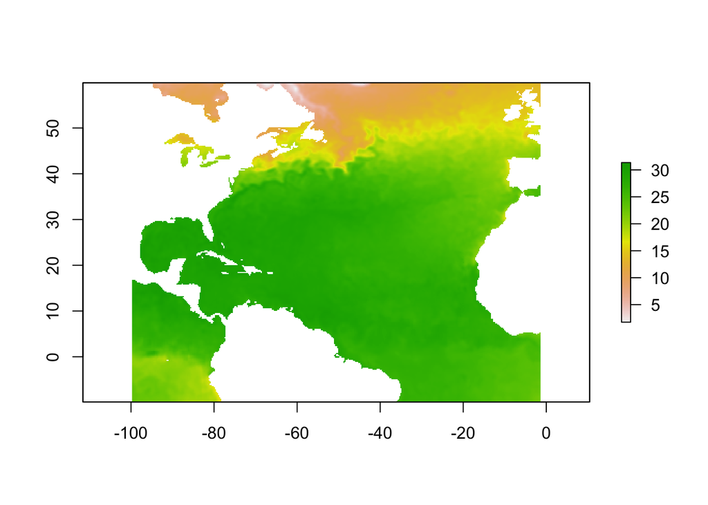

```r
plot (SST)
```

You can also plot GeoJSON data with Leaflet. First, convert your shape files to GeoJSON using the ogr2ogr web client (https://ogre.adc4gis.com). For this to work, you must create a ZIP file containing all the elements of the Shape file.

```r
# import the GeoJSON files
irmaPolygon <- geojson_read("~/Google_Drive/irma_pgn.json", what = "sp")
irmaLine <- geojson_read("~/Google_Drive/irma_lin.json", what = "sp")
irmaPoints <- geojson_read("~/Google_Drive/irma_pts.json", what = "sp")

#
# NOTE: for some reason, geojson_read() mangles the FLDATELBL field,
# so I've used the VALIDTIME field instead.
#
labels <- as.data.frame(irmaPoints)$VALIDTIME

m <- leaflet ()
m <- addProviderTiles(m, providers$OpenTopoMap)
m <- addPolygons(m, data = irmaPolygon, color = "black", weight = "2",
                 fillColor="red", fillOpacity = 0.3)
m <- addPolylines(m, data = irmaLine)
m <- addCircleMarkers(m, data = irmaPoints, color = "red", radius = 2,
                 label = labels, labelOptions = labelOptions(noHide = TRUE, textOnly = TRUE))
m <- addCircleMarkers(m, lat=df$Lat,lng=df$Long,label=df$Name, radius = 2,
                 labelOptions = labelOptions(noHide = TRUE, textOnly = TRUE))
m <- setView(m, -82.357,23.111,zoom=4)

m
```

[interactive chart not shown]

For another example, let’s plot the Atlantic hurricanes from the 2005 season, and again overlay sea surface temperature data for a single day, 1 September 2005.

The following code block is adapted from http://r-spatial.org/r/2017/08/28/nest.html, a post on “Tidy storm trajectories”, by Edzer Pebesma. It uses a dataset of historical Atlantic hurricane storm tracks that is built into the ‘dplyr’ package. First it pulls in the latitude/longitude values of each storm, then connects them into tracks. Finally, we look exclusively at those storms in the 2005 season.

```r
storms
```

```
## # A tibble: 10,010 x 13
##     name  year month   day  hour   lat  long              status category
##    <chr> <dbl> <dbl> <int> <dbl> <dbl> <dbl>               <chr>    <ord>
##  1   Amy  1975     6    27     0  27.5 -79.0 tropical depression       -1
##  2   Amy  1975     6    27     6  28.5 -79.0 tropical depression       -1
##  3   Amy  1975     6    27    12  29.5 -79.0 tropical depression       -1
##  4   Amy  1975     6    27    18  30.5 -79.0 tropical depression       -1
##  5   Amy  1975     6    28     0  31.5 -78.8 tropical depression       -1
##  6   Amy  1975     6    28     6  32.4 -78.7 tropical depression       -1
##  7   Amy  1975     6    28    12  33.3 -78.0 tropical depression       -1
##  8   Amy  1975     6    28    18  34.0 -77.0 tropical depression       -1
##  9   Amy  1975     6    29     0  34.4 -75.8      tropical storm        0
## 10   Amy  1975     6    29     6  34.0 -74.8      tropical storm        0
## # ... with 10,000 more rows, and 4 more variables: wind <int>,
## #   pressure <int>, ts_diameter <dbl>, hu_diameter <dbl>
```

```r
storms.sf <- storms %>% st_as_sf(coords = c("long", "lat"), crs = 4326)

storms.sf <- storms.sf %>%
  mutate(time = as.POSIXct(paste(paste(year,month,day, sep="-"),
                                 paste(hour, ":00", sep = "")))) %>%
  dplyr::select(-month, -day, -hour)

storms.nest <- storms.sf %>% group_by(name, year) %>% nest

to_line <- function(tr) st_cast(st_combine(tr), "LINESTRING") %>% .[[1]]

# crs = coordinate reference system, based on EPSG codes
tracks <- storms.nest %>% pull(data) %>% purrr::map(to_line) %>% st_sfc(crs = 4326)

# combining these storm-based geometries to the storm-based attributes:
storms.tr <- storms.nest %>% dplyr::select(-data) %>% st_sf(geometry = tracks)
storms.tr.2k5 <- subset(storms.tr, year == 2005)
```

This code comes from Luke Miller at San Jose State University in California and is based on his 2014 blog post: https://lukemiller.org/index.php/2014/11/extracting-noaa-sea-surface-temperatures-with-ncdf4/. It retrieves sea surface temperatures for a given latitude/longitude and date.

```r
#############################################################################################
# Basic OISST data load

# customize for your computer
# source ("~/Downloads/NOAA_OISST_ncdf4.R")

# Extract 2 days of data for the North Atlantic ocean.
# Customize the file paths to suit your local machine
ssts = extractOISSTdaily("~/Downloads/sst.day.mean.2005.v2.nc","~/Downloads/lsmask.oisst.v2.nc", lonW=160, lonE=359, latS=-10, latN=60, date1='2005-09-01', date2='2005-09-02')

s = brick(ssts,
          xmn = as.numeric(attr(ssts, 'dimnames')$Long[1]),
          xmx = as.numeric(attr(ssts, 'dimnames')$Long[ncol(ssts)]),
          ymn = as.numeric(attr(ssts, 'dimnames')$Lat[nrow(ssts)]),
          ymx = as.numeric(attr(ssts, 'dimnames')$Lat[1]),
          crs = '+proj=longlat +datum=WGS84')
s = dropLayer(s, 2)

# Necessary steps to get leaflet to plot western hemi data
# See https://github.com/r-spatial/mapview/issues/6
b = shift(s, -360)
SST <- crop(b, extent(-100,180,-90,90),snap='in') %>% trim()

#############################################################################################
```

Plot the data on an interactive map using the mapview package, which is based on Leaflet.

```r
# Generate the initial map of SSTs, and then add storm tracks
# Center view on Bermuda

m <- mapview(SST, legend = TRUE, trim = FALSE) +
  mapview(storms.tr.2k5, zcol = "name", legend = FALSE)
m@map <- m@map %>% setView(-64.768, 32.295, zoom = 3)
m
```

[interactive chart not shown]